# individual1

Jaeyeon Won

9/9/2020

## Reading in the Data Set

```r
#Reading in the data set
choco <- read.csv("https://raw.githubusercontent.com/xdaiISU/ds202materials/master/hwlabs/data/choco.csv")

#Information
str(choco)
```

```
## 'data.frame':    2312 obs. of  13 variables:
##  $ REF                 : int  2454 2458 2454 797 797 1015 1019 1011 1019 1011 ...
##  $ Company             : chr  "5150" "5150" "5150" "A. Morin" ...
##  $ Location            : chr  "U.S.A." "U.S.A." "U.S.A." "France" ...
##  $ Date                : int  2019 2019 2019 2012 2012 2013 2013 2013 2013 2013 ...
##  $ Bean_Origin         : chr  "Madagascar" "Dominican Republic" "Tanzania" "Peru" ...
##  $ Specific_Bean_Origin: chr  "Bejofo Estate, batch 1" "Zorzal, batch 1" "Kokoa Kamili, batch 1" "Peru" ...
##  $ Cocoa_Percent       : num  76 76 76 63 70 70 63 70 70 70 ...
##  $ Ingredients         : chr  "3- B,S,C" "3- B,S,C" "3- B,S,C" "4- B,S,C,L" ...
##  $ Characteristics1    : chr  "cocoa" "cocoa" "rich cocoa" "fruity" ...
##  $ Characteristics2    : chr  "blackberry" "vegetal" "fatty" "melon" ...
##  $ Characteristics3    : chr  "full body" "savory" "bready" "roasty" ...
##  $ Characteristics4    : chr  NA NA NA NA ...
##  $ Rating              : num  3.75 3.5 3.25 3.75 3.5 4 4 3.75 3.5 3.25 ...
```

## Searching for the Best Chocolates

We will be exploring what aspects of the chocolates may affect taste. Before setting off to the exploration, answer the following questions.

**1. How are the ratings distributed? Create both a histogram and a boxplot and describe them. Don’t forget to mention outliers, if there are any.**

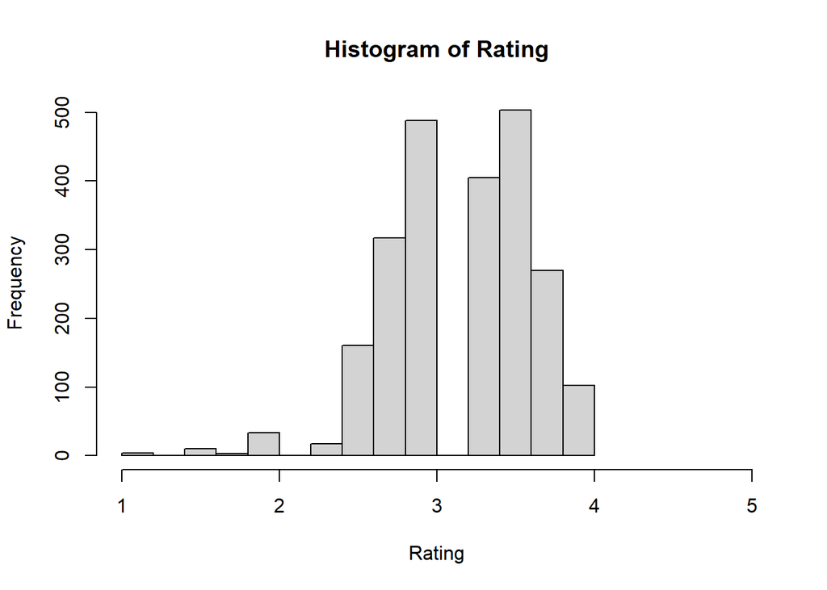

```r
#Histogram
hist(choco$Rating,
     xlim = c(1,5),
     main = 'Histogram of Rating',
     xlab = 'Rating')
```

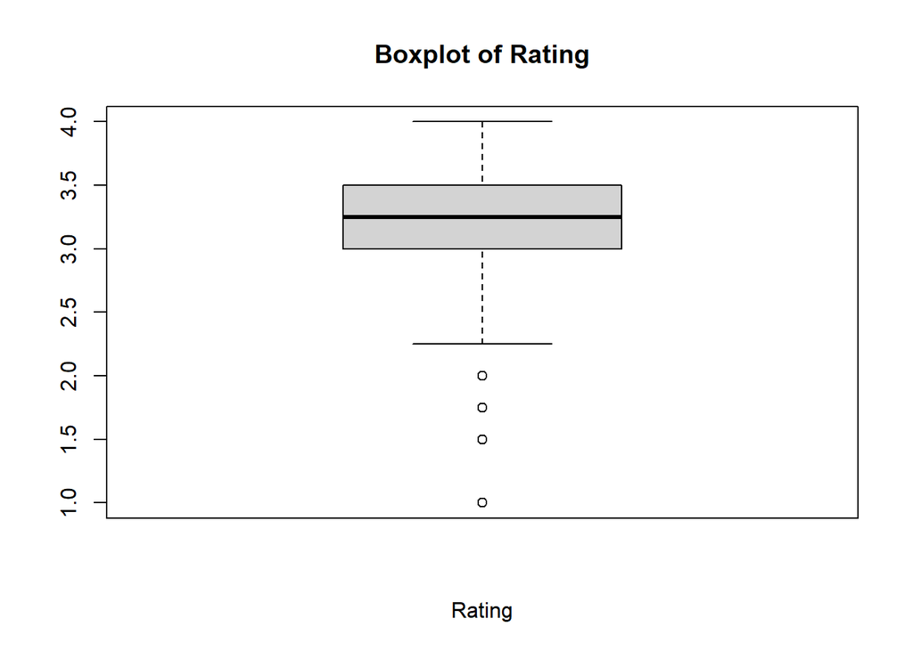

```r
#Boxplot
boxplot(choco$Rating,
        main = 'Boxplot of Rating',
        xlab = 'Rating')
```

The rating of chocolates is on the scale from 1.0 to 5.0 where (1.0-1.9) is for ‘Unpleasant’, (2.0-2.9) is for ‘Disappointing’, (3.0-3.49) is for ‘Recommended’, (3.5-3.9) is for ‘Highly Recommended’, and (4.0-5.0) is for ‘Outstanding’. According to the histogram and boxplot, the distribution of chocolates is a little bit skewed to the left and bimodal with multiple outliers in the lower range below a rating of 2.0. A lot of chocolates are concentrated in the higher rating range of ‘Disappointing’(2.6-2.9), higher rating range of ‘Recommended’ (3.2-3.49), and lower rating range of ‘Highly Recommended’ (3.5-3.6).One interesting feature is that there was no chocolate with a rating between 3.0 and 3.24 as well as above 4.0. More specifically about the baxplot, the lowest score was 1.0, the highest score was 4.0, and the median score was around 3.25.

**2. How does the number of ratings depend on the year? Draw a bar chart of the number of reports.**

```r
#Changing the type of Date variable (from integer to factor)
Year = as.factor(choco$Date)
str(Year)
```

```
##  Factor w/ 15 levels "2006","2007",..: 14 14 14 7 7 8 8 8 8 8 ...
```

```r
#Checking the distribution of each level
table(Year)
```

```
## Year
## 2006 2007 2008 2009 2010 2011 2012 2013 2014 2015 2016 2017 2018 2019 2020
##   62   73   92  123  110  163  194  184  247  284  219  105  228  195   33
```

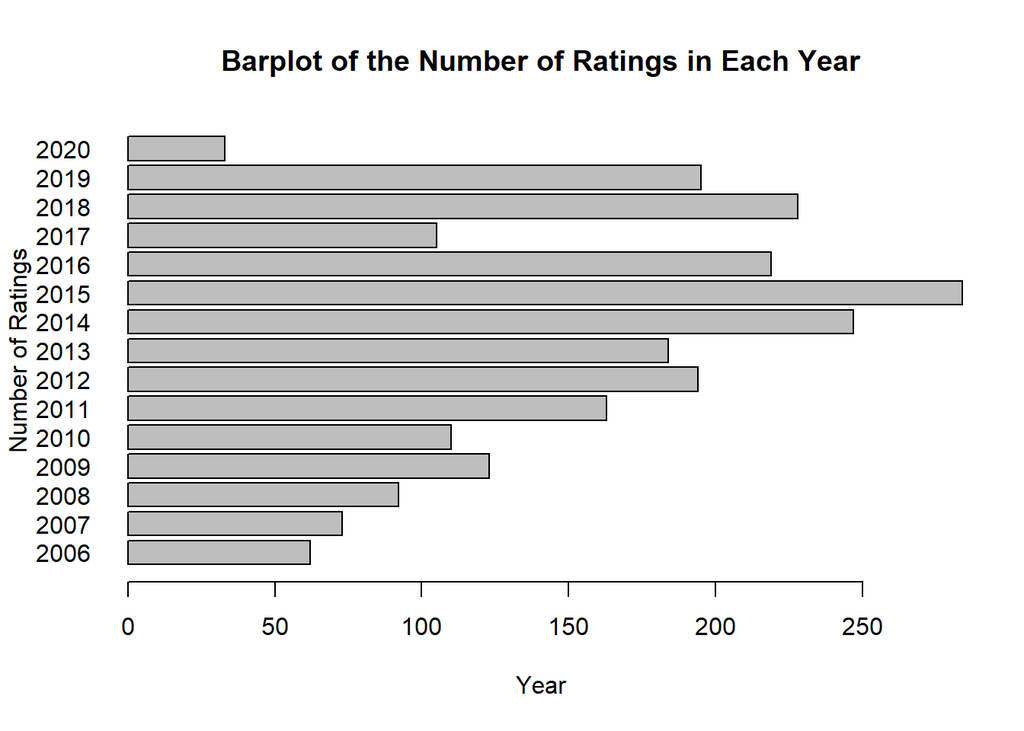

```r
#Barplot
barplot(table(Year),
        main = 'Barplot of the Number of Ratings in Each Year',
        xlab = 'Year',
        ylab = 'Number of Ratings',
        horiz = TRUE,
        las = 1)
```

**3. Do ratings depend on the cacao percentage of a chocolate bar? Create both numerical and graphical summaries, and explain.**

```r
#Numerical Summary
#Subsetting
Unpleasant = choco[(choco$Rating >= 1.0) & (choco$Rating <= 1.9), ]
Disappointing = choco[(choco$Rating >= 2.0) & (choco$Rating <= 2.9), ]
Recommended = choco[(choco$Rating >= 3.0) & (choco$Rating <= 3.49), ]
HighlyRecommended = choco[(choco$Rating >= 3.5) & (choco$Rating <= 3.9), ]
Outstanding = choco[(choco$Rating >= 4.0) & (choco$Rating <= 5.0), ]
#Saving the average cocoa percent for each subset in a vector
mean_cocoa_percent = c(mean(Unpleasant$Cocoa_Percent),
                       mean(Disappointing$Cocoa_Percent),
                       mean(Recommended$Cocoa_Percent),
                       mean(HighlyRecommended$Cocoa_Percent),
                       mean(Outstanding$Cocoa_Percent))
levels = c("Unpleasant", "Disappointing", "Recommended", "HighlyRecommended", "Outstanding")
dataframe = data.frame(levels, mean_cocoa_percent)
dataframe
```

```
##              levels mean_cocoa_percent
## 1        Unpleasant           84.29412
## 2     Disappointing           72.31784
## 3       Recommended           71.56327
## 4 HighlyRecommended           71.12549
## 5       Outstanding           70.77451
```

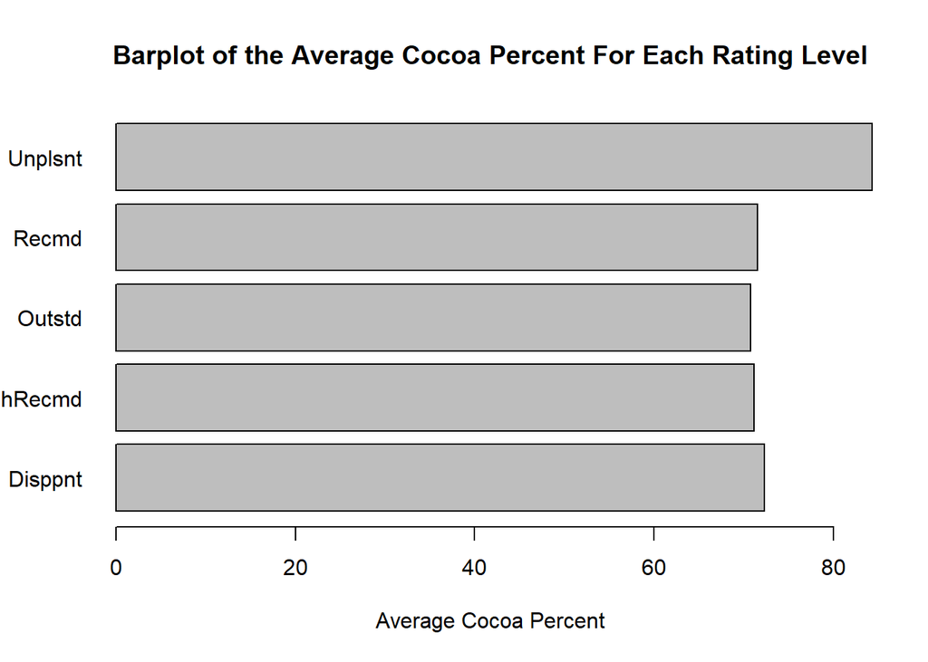

```r
#Graphical Summary
#Barplot
levels2 = c("Unplsnt", "Disppnt", "Recmd", "hRecmd", "Outstd")
barplot(dataframe$mean_cocoa_percent ~ levels2,
        main = 'Barplot of the Average Cocoa Percent For Each Rating Level',
        xlab = 'Average Cocoa Percent',
        ylab = '',
        horiz = TRUE,
        las = 1)
```

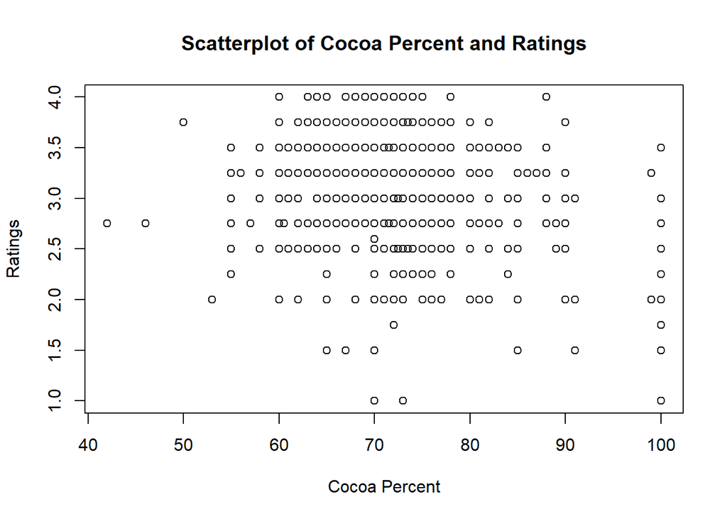

```r
#Scatterplot
plot(choco$Cocoa_Percent, choco$Rating,
     main = "Scatterplot of Cocoa Percent and Ratings",
     xlab = "Cocoa Percent", ylab = "Ratings")
```

I firstly grouped the ratings in 5 levels based on the criteria provided. After that, I got the mean cocoa percent for each group. According to the numerical summary and graphical summary of the mean cocoa percent, We can see that as the rating gets lower (from Outstanding to Unpleasant), the mean cocoa percent gets higher. Specifically, Unpleasant rating has mean cocoa percent of 84.29% while Outstanding rating has that of 70.77%. In scatter plot, we can see that the majority of the chocolates in higher ratings tend to have cocoa percent between 60~80% while the middle-rating chocolates include very high cocoa percent (100%). However, since the ratings are ordinal variable, we cannot see a distinct pattern in the scatter plot, opposed to the bar plot.

**Now, we are ready to explore.**

**4. How do different characteristics of the chocolate compare? To elaborate, which characteristics tend to be more favorable and which ones are not? Create both numerical and graphical summaries, and explain.**

```r
library(dplyr)
#Favorable Characteristics
#Creating summaries
good_Characteristics = choco %>%
  select(Characteristics1, Rating) %>%
  group_by(Characteristics1) %>%
  summarise(Average_Rating = mean(Rating)) %>%
  arrange(desc(Average_Rating)) %>%
  top_n(10)
#Numerical summaries
good_Characteristics
```

```
## # A tibble: 11 x 2
##    Characteristics1         Average_Rating
##    <chr>                             <dbl>
##  1 cardamon                              4
##  2 chocolate covered banana              4
##  3 distinct lemon                        4
##  4 large nibs                            4
##  5 ligt color                            4
##  6 mild tart                             4
##  7 pronounced berry                      4
##  8 simple red berry                      4
##  9 smoth                                 4
## 10 sweet spice                           4
## 11 well defined                          4
```

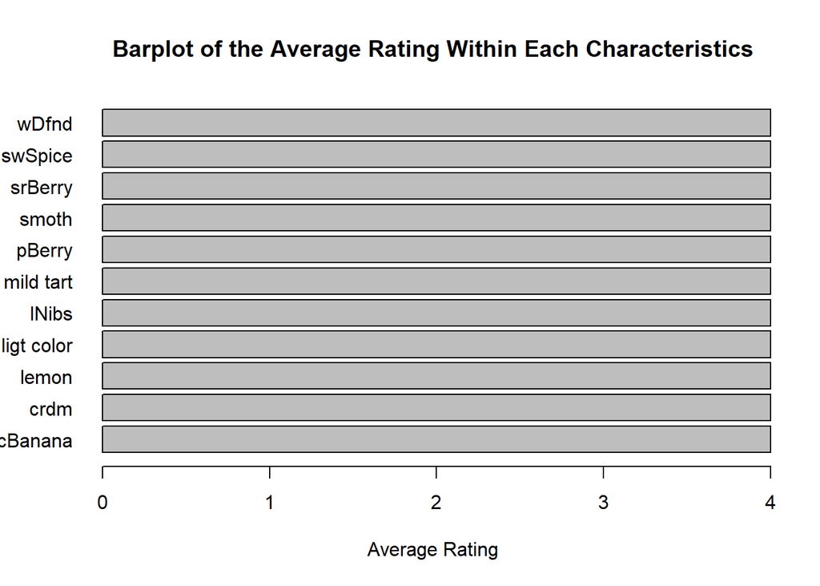

```r
#Graphical summaries
levels(good_Characteristics$Characteristics1) = c("crdm", "cBanana", "lemon", "lNibs", "ligt color", "mild tart", "pBerry", "srBerry", "smoth", "swSpice", "wDfnd")

barplot(good_Characteristics$Average_Rating ~ levels(good_Characteristics$Characteristics1),
        main = 'Barplot of the Average Rating Within Each Characteristics',
        xlab = 'Average Rating',
        ylab = '',
        horiz = TRUE,
        las = 1)
```

```r
#Unfavorable Characteristics
#Creating summaries
bad_Characteristics = choco %>%
  select(Characteristics1, Rating) %>%
  group_by(Characteristics1) %>%
  summarise(Average_Rating = mean(Rating)) %>%
  arrange(Average_Rating) %>%
  top_n(-10)
#Numerical summaries
bad_Characteristics
```

```
## # A tibble: 12 x 2
##    Characteristics1      Average_Rating
##    <chr>                          <dbl>
##  1 this is not chocolate           1
##  2 chemical                        1.5
##  3 high intensity bitter           1.5
##  4 klingy                          1.5
##  5 very nutty                      1.75
##  6 bitter coffee flavor            2
##  7 fresh nibs                      2
##  8 malitol                         2
##  9 multiple off flavors            2
## 10 non descript                    2
## 11 sandpaper                       2
## 12 some fruit                      2
```

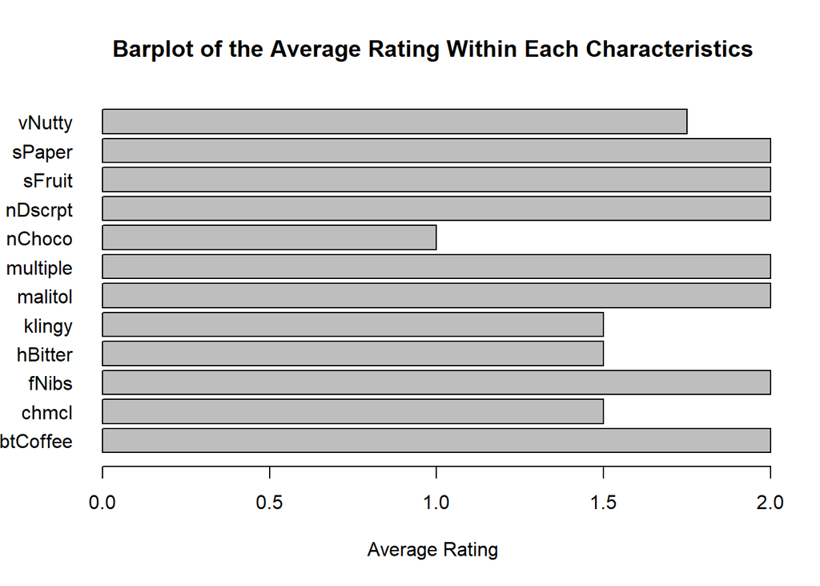

```r
#Graphical summaries
levels(bad_Characteristics$Characteristics1) = c("nChoco", "chmcl", "hBitter", "klingy", "vNutty", "btCoffee", "fNibs", "malitol", "multiple", "nDscrpt", "sPaper", "sFruit")

barplot(bad_Characteristics$Average_Rating ~ levels(bad_Characteristics$Characteristics1),
        main = 'Barplot of the Average Rating Within Each Characteristics',
        xlab = 'Average Rating',
        ylab = '',
        horiz = TRUE,
        las = 1)
```

We will only look at the observations in Characteristics 1. I got the mean rating for each characteristic in Characteristics 1 and selected the top 10 characteristics to pick the favorable characteristics. The top 10 favorable characteristics are cardamon, chocolate covered banana, distinct lemon, large nibs, ligt color, mild tart, pronounced berry, simple red berry, smoth, and sweet spice. They all have an average rating of 4.0. In contrast, the bottom 10 favorable characteristics (unfavorable) are this is not chocolate, chemical, high intensity bitter, klingy, very nutty, bitter coffee flavor, fresh nibs, malitol, multiple off, flavors, and non descript. The ratings vary from 1.0 to 2.0.

**5. Brainstorm two analyses you would like to perform with your teammate. Describe in plain language what comparisons are you making. Create suitable numerical and graphical summaries for your analyses. Describe the results.**

**5.1 How do chocolates have different ratings for different origins?**

```r
#Creating summaries
origins = choco %>%
  select(Bean_Origin, Rating) %>%
  group_by(Bean_Origin) %>%
  summarise(Average_Rating = mean(Rating)) %>%
  arrange(desc(Average_Rating)) %>%
  top_n(5)
#Numerical summaries
origins
```

```
## # A tibble: 5 x 2
##   Bean_Origin         Average_Rating
##   <chr>                        <dbl>
## 1 Tobago                        3.62
## 2 Sao Tome & Principe           3.5
## 3 Solomon Islands               3.45
## 4 Congo                         3.32
## 5 Thailand                      3.3
```

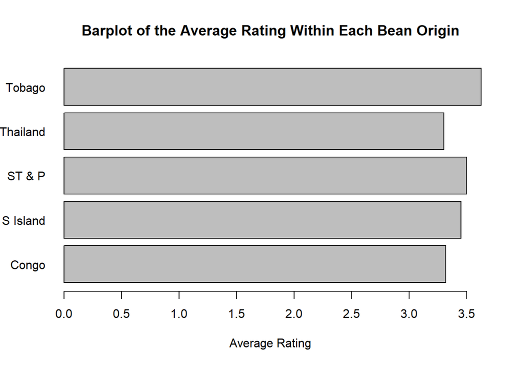

```r
#Graphical summaries
levels(origins$Bean_Origin) = c("Tobago", "ST & P", "S Island", "Congo", "Thailand")

barplot(origins$Average_Rating ~ levels(origins$Bean_Origin),
        main = 'Barplot of the Average Rating Within Each Bean Origin',
        xlab = 'Average Rating',
        ylab = '',
        horiz = TRUE,
        las = 1)
```

**5.2 How do chocolates have different ratings for different bean companies?**

```r
#Creating summaries
company = choco %>%
  select(Company, Rating) %>%
  group_by(Company) %>%
  summarise(Average_Rating = mean(Rating)) %>%
  arrange(desc(Average_Rating)) %>%
  top_n(5)
#Numerical summaries
company
```

```
## # A tibble: 5 x 2
##   Company                              Average_Rating
##   <chr>                                         <dbl>
## 1 Tobago Estate (Pralus)                         4
## 2 Heirloom Cacao Preservation (Zokoko)           3.88
## 3 Ocelot                                         3.88
## 4 Matale                                         3.81
## 5 Patric                                         3.79
```

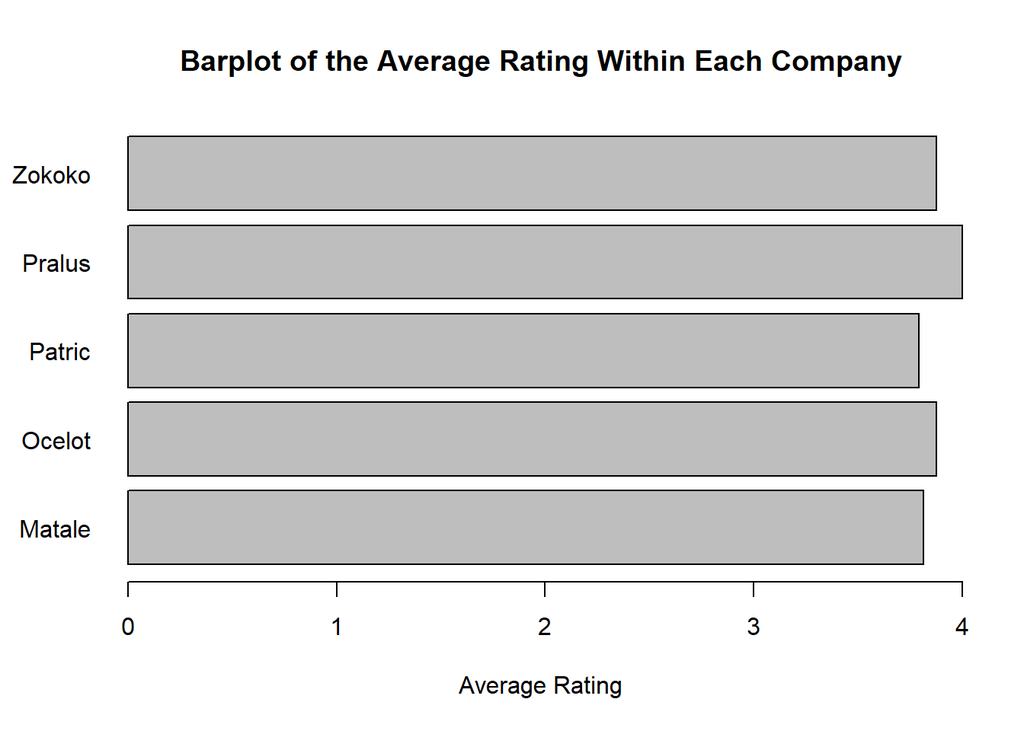

```r
#Graphical summaries
levels(company$Company) = c("Pralus", "Zokoko", "Ocelot", "Matale", "Patric")

barplot(company$Average_Rating ~ levels(company$Company),
        main = 'Barplot of the Average Rating Within Each Company',
        xlab = 'Average Rating',
        ylab = '',
        horiz = TRUE,
        las = 1)
```